# Reynolds

Julie Overgaard

2024-05-01

## Setting up the right packages:

## Getting the Reynolds pdf text:

```r
reynolds <- pdf_text('dataRey/Reynolds, The Use of Feudalism in Comparative History.pdf')
reynolds_df <- data.frame(text = reynolds) %>%
  mutate(page = 1:n())

reynolds_text <- reynolds_df %>%
  filter(page %in% 1:20) %>%
  mutate(text = str_split(text, '\n')) %>%
  unnest(text)
```

## Cut out the first pages

-Setting it up so reynolds_true contains only Reynolds text

```r
reynolds_true <- reynolds[3:30]
```

### Some wrangling:

- Split up pages into separate lines (separated by `\n`) using `stringr::str_split()`
- Unnest into regular columns using `tidyr::unnest()`
- Remove leading/trailing white space with `stringr::str_trim()`

```r
reynolds_df <- data.frame(reynolds_true) %>%
  mutate(text_full1 = str_split(reynolds_true, pattern = '\n')) %>%
  unnest(text_full1) %>%
  mutate(text_full1 = str_trim(text_full1))
view(reynolds_df)
```

Now each line, on each page, is its own row, with extra starting & trailing spaces removed.

### Get the tokens (individual words) in tidy format

Use `tidytext::unnest_tokens()` (which pulls from the `tokenizer`) package, to split columns into tokens. We are interested in *words*, so that’s the token we’ll use:

```r
reynolds_tokens <- reynolds_df %>%
  unnest_tokens(word, text_full1)
```

## Counting the words

```r
reynolds_wc <- reynolds_tokens %>%
  count(word) %>%
  arrange(-n)
reynolds_wc
```

```
## # A tibble: 2,008 × 2
##    word      n
##    <chr> <int>
##  1 the     654
##  2 of      476
##  3 to      321
##  4 and     311
##  5 in      275
##  6 that    151
##  7 a       139
##  8 or      124
##  9 it      114
## 10 as      110
## # ℹ 1,998 more rows
```

## Removing stop words

```r
reynolds_stop <- reynolds_tokens %>%
  anti_join(stop_words) %>%
  select(-reynolds_true)
```

```r
reynolds_swc <- reynolds_stop %>%
  count(word) %>%
  arrange(-n)
reynolds_swc
```

```
## # A tibble: 1,624 × 2
##    word            n
##    <chr>       <int>
##  1 feudalism      81
##  2 society        51
##  3 history        48
##  4 feudal         46
##  5 medieval       42
##  6 weber          40
##  7 comparative    39
##  8 bloch          37
##  9 word           33
## 10 historians     30
## # ℹ 1,614 more rows
```

## Creating a word cloud

```r
length(unique(reynolds_stop$word))
```

```
## [1] 1624
```

```r
## 1624 unique words

## Getting the top 100 words
reynolds_top100 <- reynolds_stop %>%
  count(word) %>%
  arrange(-n) %>%
  head(100)
reynolds_top100
```

```
## # A tibble: 100 × 2
##    word            n
##    <chr>       <int>
##  1 feudalism      81
##  2 society        51
##  3 history        48
##  4 feudal         46
##  5 medieval       42
##  6 weber          40
##  7 comparative    39
##  8 bloch          37
##  9 word           33
## 10 historians     30
## # ℹ 90 more rows
```

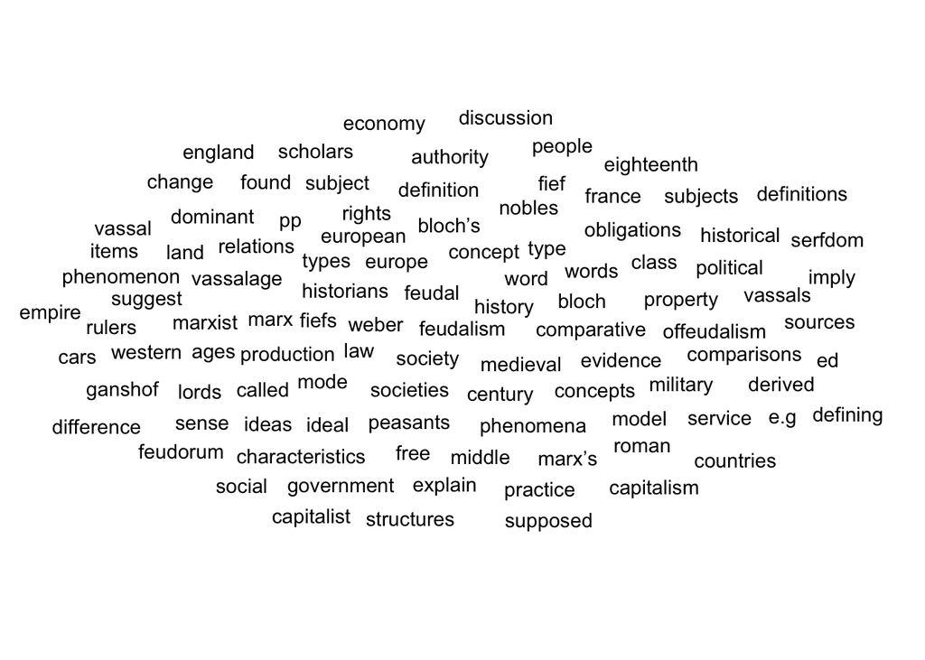

```r
reynolds_cloud <- ggplot(data = reynolds_top100, aes(label = word)) +
  geom_text_wordcloud() +
  theme_minimal()
reynolds_cloud
```

## Customizing the cloud

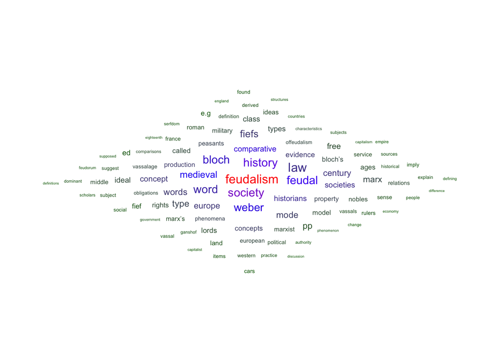

```r
ggplot(data = reynolds_top100, aes(label = word, size = n)) +
  geom_text_wordcloud_area(aes(color = n), shape = "diamond") +
  scale_size_area(max_size = 12) +
  scale_color_gradientn(colors = c("darkgreen","blue","red")) +
  theme_minimal()
```

## Sentiment Analysis - aflinn

-The AFINN lexicon assigns words with a score that runs between -5 and 5, with negative scores indicating negative sentiment and positive scores indicating positive sentiment. -“afinn”: Words ranked from -5 (very negative) to +5 (very positive)

```r
reynolds_afinn <- reynolds_stop %>%
  inner_join(get_sentiments("afinn"))
reynolds_afinn
```

```
## # A tibble: 207 × 2
##    word        value
##    <chr>       <dbl>
##  1 trouble        -2
##  2 oppressive     -2
##  3 hope            2
##  4 avoid          -1
##  5 significant     1
##  6 free            1
##  7 free            1
##  8 grant           1
##  9 legal           1
## 10 restricted     -2
## # ℹ 197 more rows
```

Let’s find some counts (by sentiment ranking):

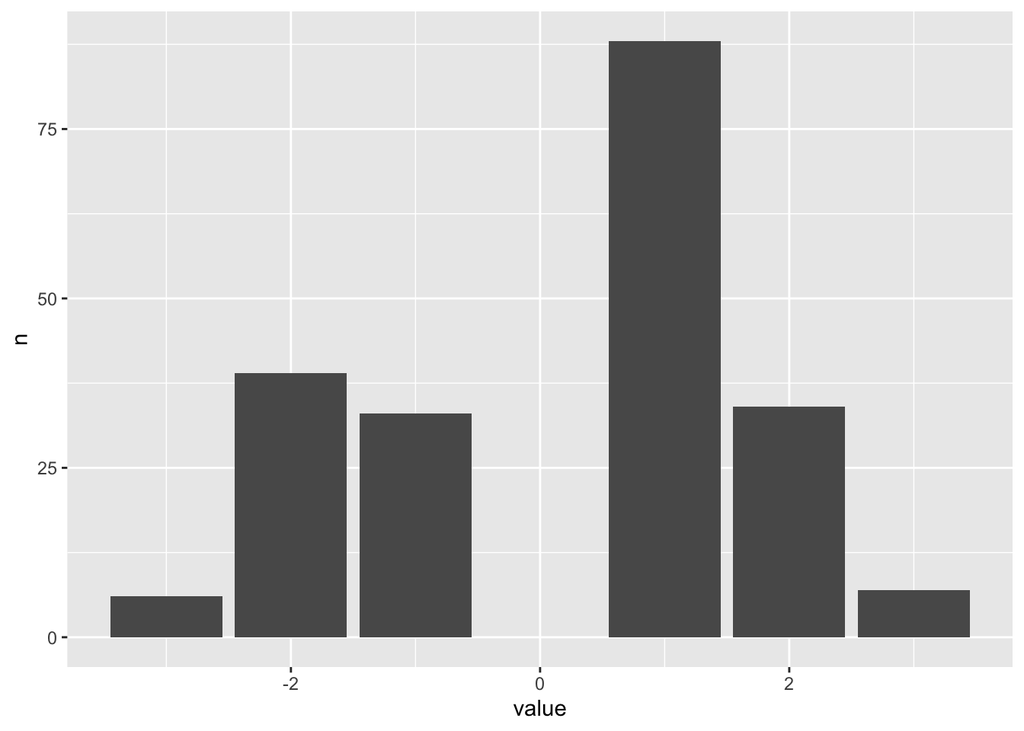

```r
reynolds_afinn_hist <- reynolds_afinn %>%
  count(value)

# Plot them:
ggplot(data = reynolds_afinn_hist, aes(x = value, y = n)) +
  geom_col()
```

Looking closer on some of the positive words (1)

```r
reynolds_afinn1 <- reynolds_afinn %>%
  filter(value == 1) %>%
  head(50)
reynolds_afinn1
```

```
## # A tibble: 50 × 2
##    word        value
##    <chr>       <dbl>
##  1 significant     1
##  2 free            1
##  3 free            1
##  4 grant           1
##  5 legal           1
##  6 share           1
##  7 authority       1
##  8 authority       1
##  9 grants          1
## 10 easy            1
## # ℹ 40 more rows
```

```r
# Check the unique 1-score words:
unique(reynolds_afinn1$word)
```

```
##  [1] "significant" "free"        "grant"       "legal"       "share"
##  [6] "authority"   "grants"      "easy"        "granted"     "solutions"
## [11] "absorbed"    "increased"   "attracted"   "spirit"      "matter"
## [16] "agree"       "accept"      "stimulated"  "prospect"    "accepted"
## [21] "agreed"      "accepting"   "motivation"
```

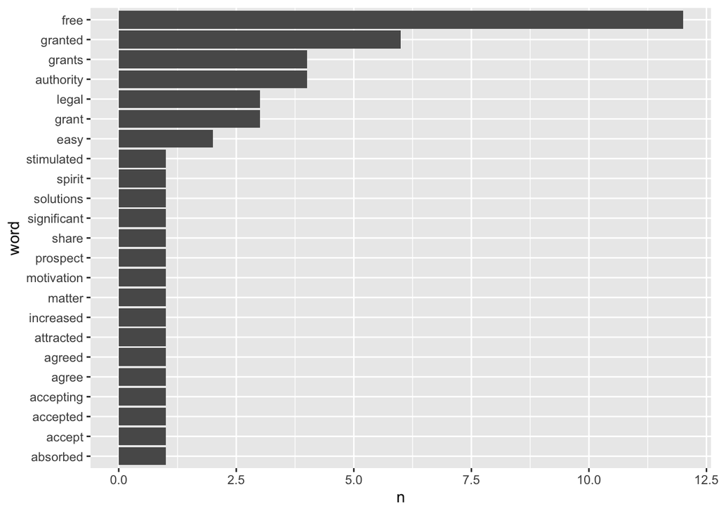

```r
# Count & plot them
reynolds_afinn1_n <- reynolds_afinn1 %>%
  count(word, sort = TRUE) %>%
  mutate(word = fct_reorder(factor(word), n))


ggplot(data = reynolds_afinn1_n, aes(x = word, y = n)) +
  geom_col() +
  coord_flip()
```

```r
reynolds_summary <- reynolds_afinn %>%
  summarize(
    mean_score = mean(value),
    median_score = median(value)
  )
reynolds_summary
```

```
## # A tibble: 1 × 2
##   mean_score median_score
##        <dbl>        <dbl>
## 1      0.232            1
```

-The mean and median indicate *slightly* positive overall sentiments based on the AFINN lexicon.

## Sentiment analysis - nrc

-The nrc lexicon categorizes words in a binary fashion (“yes”/“no”) into categories of positive, negative, anger, anticipation, disgust, fear, joy, sadness, surprise, and trust. -We can use the NRC lexicon to start “binning” text by the feelings they’re typically associated with. As above, we’ll use inner_join() to combine the idig non-stopword text with the nrc lexicon:

```r
reynolds_nrc <- reynolds_stop %>%
  inner_join(get_sentiments("nrc"))
reynolds_nrc
```

```
## # A tibble: 1,644 × 2
##    word      sentiment
##    <chr>     <chr>
##  1 feudalism anger
##  2 feudalism negative
##  3 feudalism sadness
##  4 word      positive
##  5 word      trust
##  6 feudalism anger
##  7 feudalism negative
##  8 feudalism sadness
##  9 feudal    negative
## 10 feudal    negative
## # ℹ 1,634 more rows
```

Wait, won’t that exclude some of the words in our text? YES! We should check which are excluded using `anti_join()`:

```r
reynolds_exclude <- reynolds_stop %>%
  anti_join(get_sentiments("nrc"))

# View(reynolds_exclude)

# Count to find the most excluded:
reynolds_exclude_n <- reynolds_exclude %>%
  count(word, sort = TRUE)

head(reynolds_exclude_n)
```

```
## # A tibble: 6 × 2
##   word            n
##   <chr>       <int>
## 1 society        51
## 2 history        48
## 3 medieval       42
## 4 weber          40
## 5 comparative    39
## 6 bloch          37
```

Counts

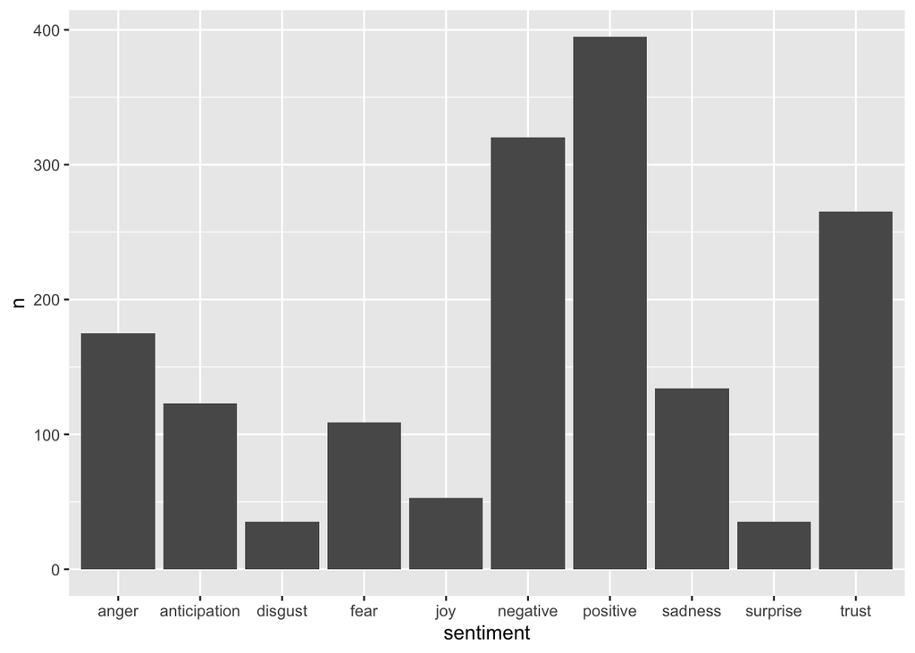

```r
reynolds_nrc_n <- reynolds_nrc %>%
  count(sentiment, sort = TRUE)

# And plot them:

ggplot(data = reynolds_nrc_n, aes(x = sentiment, y = n)) +
  geom_col()
```

Or count by sentiment *and* word, then facet:

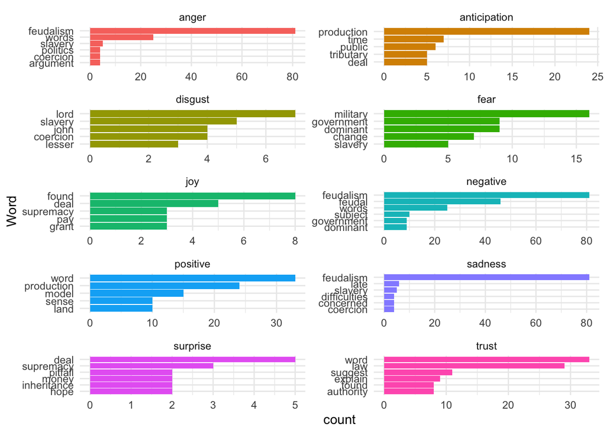

```r
reynolds_nrc_n5 <- reynolds_nrc %>%
  count(word,sentiment, sort = TRUE) %>%
  group_by(sentiment) %>%
  top_n(5) %>%
  ungroup()

reynolds_nrc_gg <- ggplot(data = reynolds_nrc_n5, aes(x = reorder(word,n), y = n, fill = sentiment)) +
  geom_col(show.legend = FALSE) +
  facet_wrap(~sentiment, ncol = 2, scales = "free") +
  coord_flip() +
  theme_minimal() +
  labs(x = "Word", y = "count")

# Show it
reynolds_nrc_gg
```

## Big picture takeaway

There are serious limitations of sentiment analysis using existing lexicons, and you should **think really hard** about your findings and if a lexicon makes sense for your study. Otherwise, word counts and exploration alone can be useful!

### Credits:

This tutorial is inspired by Allison Horst’s Advanced Statistics and Data Analysis.